# Lab 3: Gesture Recognition using Convolutional Neural Networks

**Deadlines**: Feb 8, 5:00PM

**Late Penalty**: There is a penalty-free grace period of one hour past the deadline. Any work that is submitted between 1 hour and 24 hours past the deadline will receive a 20% grade deduction. No other late work is accepted. Quercus submission time will be used, not your local computer time. You can submit your labs as many times as you want before the deadline, so please submit often and early.

**Grading TAs**: Geoff Donoghue

This lab is based on an assignment developed by Prof. Lisa Zhang.

This lab will be completed in two parts. In Part A you will you will gain experience gathering your own data set (specifically images of hand gestures), and understand the challenges involved in the data cleaning process. In Part B you will train a convolutional neural network to make classifications on different hand gestures. By the end of the lab, you should be able to:

1. Generate and preprocess your own data
2. Load and split data for training, validation and testing
3. Train a Convolutional Neural Network
4. Apply transfer learning to improve your model

Note that for this lab we will not be providing you with any starter code. You should be able to take the code used in previous labs, tutorials and lectures and modify it accordingly to complete the tasks outlined below.

### What to submit

**Submission for Part A:**  
Submit a zip file containing your images. Three images each of American Sign Language gestures for letters A - I (total of 27 images). You will be required to clean the images before submitting them. Details are provided under Part A of the handout.

Individual image file names should follow the convention of student-number_Alphabet_file-number.jpg (e.g. 100343434_A_1.jpg).

**Submission for Part B:**  
Submit a PDF file containing all your code, outputs, and write-up from parts 1-5. You can produce a PDF of your Google Colab file by going to **File > Print** and then save as PDF. The Colab instructions has more information. Make sure to review the PDF submission to ensure that your answers are easy to read. Make sure that your text is not cut off at the margins.

**Do not submit any other files produced by your code.**

Include a link to your colab file in your submission.

Please use Google Colab to complete this assignment. If you want to use Jupyter Notebook, please complete the assignment and upload your Jupyter Notebook file to Google Colab for submission.

## Colab Link

Include a link to your colab file here

Colab Link: https://colab.research.google.com/drive/16cfA6vg7gJyE7Y7gBaYUwY8WF5Vkx4__?usp=sharing

## Part A. Data Collection [10 pt]

So far, we have worked with data sets that have been collected, cleaned, and curated by machine learning researchers and practitioners. Datasets like MNIST and CIFAR are often used as toy examples, both by students and by researchers testing new machine learning models.

In the real world, getting a clean data set is never that easy. More than half the work in applying machine learning is finding, gathering, cleaning, and formatting your data set.

The purpose of this lab is to help you gain experience gathering your own data set, and understand the challenges involved in the data cleaning process.

### American Sign Language

American Sign Language (ASL) is a complete, complex language that employs signs made by moving the hands combined with facial expressions and postures of the body. It is the primary language of many North Americans who are deaf and is one of several communication options used by people who are deaf or hard-of-hearing.

The hand gestures representing English alphabet are shown below. This lab focuses on classifying a subset of these hand gesture images using convolutional neural networks. Specifically, given an image of a hand showing one of the letters A-I, we want to detect which letter is being represented.

[figure not shown]

### Generating Data

We will produce the images required for this lab by ourselves. Each student will collect, clean and submit three images each of Americal Sign Language gestures for letters A - I (total of 27 images) Steps involved in data collection

1. Familiarize yourself with American Sign Language gestures for letters from A - I (9 letters).
2. Take three pictures at slightly different orientation for each letter gesture using your mobile phone.
   - Ensure adequate lighting while you are capturing the images.
   - Use a white wall as your background.
   - Use your right hand to create gestures (for consistency).
   - Keep your right hand fairly apart from your body and any other obstructions.
   - Avoid having shadows on parts of your hand.
3. Transfer the images to your laptop for cleaning.

### Cleaning Data

To simplify the machine learning the task, we will standardize the training images. We will make sure that all our images are of the same size (224 x 224 pixels RGB), and have the hand in the center of the cropped regions.

You may use the following applications to crop and resize your images:

**Mac**

- Use Preview: – Holding down CMD + Shift will keep a square aspect ratio while selecting the hand area. – Resize to 224x224 pixels.

**Windows 10**

- Use Photos app to edit and crop the image and keep the aspect ratio a square.
- Use Paint to resize the image to the final image size of 224x224 pixels.

**Linux**

- You can use GIMP, imagemagick, or other tools of your choosing. You may also use online tools such as http://picresize.com All the above steps are illustrative only. You need not follow these steps but following these will ensure that you produce a good quality dataset. You will be judged based on the quality of the images alone. Please do not edit your photos in any other way. You should not need to change the aspect ratio of your image. You also should not digitally remove the background or shadows—instead, take photos with a white background and minimal shadows.

### Accepted Images

Images will be accepted and graded based on the criteria below

1. The final image should be size 224x224 pixels (RGB).
2. The file format should be a .jpg file.
3. The hand should be approximately centered on the frame.
4. The hand should not be obscured or cut off.
5. The photos follows the ASL gestures posted earlier.
6. The photos were not edited in any other way (e.g. no electronic removal of shadows or background).

### Submission

Submit a zip file containing your images. There should be a total of 27 images (3 for each category)

1. Individual image file names should follow the convention of student-number_Alphabet_file-number.jpg (e.g. 100343434_A_1.jpg)
2. Zip all the images together and name it with the following convention: last-name_student-number.zip (e.g. last-name_100343434.zip).
3. Submit the zipped folder. We will be anonymizing and combining the images that everyone submits. We will announce when the combined data set will be available for download.

[figure not shown]

## Part B. Building a CNN [50 pt]

For this lab, we are not going to give you any starter code. You will be writing a convolutional neural network from scratch. You are welcome to use any code from previous labs, lectures and tutorials. You should also write your own code.

You may use the PyTorch documentation freely. You might also find online tutorials helpful. However, all code that you submit must be your own.

Make sure that your code is vectorized, and does not contain obvious inefficiencies (for example, unecessary for loops, or unnecessary calls to unsqueeze()). Ensure enough comments are included in the code so that your TA can understand what you are doing. It is your responsibility to show that you understand what you write.

**This is much more challenging and time-consuming than the previous labs.** Make sure that you give yourself plenty of time by starting early.

### 1. Data Loading and Splitting [5 pt]

Download the anonymized data provided on Quercus. To allow you to get a heads start on this project we will provide you with sample data from previous years. Split the data into training, validation, and test sets.

Note: Data splitting is not as trivial in this lab. We want our test set to closely resemble the setting in which our model will be used. In particular, our test set should contain hands that are never seen in training!

Explain how you split the data, either by describing what you did, or by showing the code that you used. Justify your choice of splitting strategy. How many training, validation, and test images do you have?

For loading the data, you can use plt.imread as in Lab 1, or any other method that you choose. You may find torchvision.datasets.ImageFolder helpful. (see https://pytorch.org/docs/stable/torchvision/datasets.html?highlight=image%20folder#torchvision.datasets.ImageFolder )

**Answer:** I manually split the data into three folders which are called train, validation and test. Also, these three folders do not have the same image and have the same proportion of each class in each set. And I split them in ratio of approximately 80:10:10. The number of training, validation, and test images are 1904, 266 and 261 respectively.

```python
# Since the function writes files to disk, you will need to mount
# your Google Drive. If you are working on the lab locally, you
# can comment out this code.

from google.colab import drive
drive.mount('/content/gdrive')
```

```python
import numpy as np
import time
import os
import torch
import torch.nn as nn
import torch.nn.functional as F
import torch.optim as optim
import torchvision
from torchvision import datasets, models, transforms
from torch.utils.data.sampler import SubsetRandomSampler
import matplotlib.pyplot as plt
```

```python
rm -rf /root/datasets/Lab_3b_Gesture_Dataset
```

```python
#data path on google drive
!unzip '/content/gdrive/My Drive/APS360/Lab_3b_Gesture_Dataset.zip' -d '/root/datasets'
```

[output not shown]

[output cut: 4928 more lines]

[output not shown]

```python
#define training and test data directories
data_dir= '/root/datasets/Lab_3b_Gesture_Dataset'
train_dir=os.path.join(data_dir, 'train/')
val_dir=os.path.join(data_dir, 'validation/')
test_dir=os.path.join(data_dir, 'test/')

#classes are folders in each directory with these names
classes = ['A', 'B', 'C', 'D', 'E', 'F', 'G', 'H', 'I']
```

```python
#load and transform data using ImageFolder

#resize all images to 224 x 224
data_transform = transforms.Compose([transforms.CenterCrop([224,224]), transforms.ToTensor()])

train_data=datasets.ImageFolder(train_dir, transform=data_transform)
val_data= datasets.ImageFolder(val_dir, transform=data_transform)
test_data= datasets.ImageFolder(test_dir, transform=data_transform)

#print out some data stats
print('Num training images: ', len(train_data))
print('Num validation images: ', len(val_data))
print('Num test images: ', len(test_data))
```

```
Num training images:  1904
Num validation images:  266
Num test images:  261
```

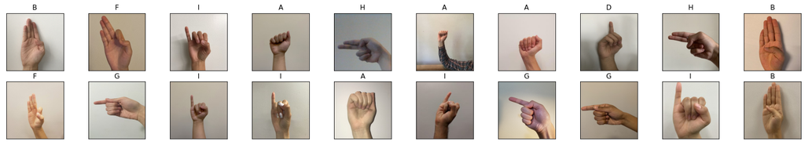

```python
#define dataloader parameters
batch_size=256
num_workers=0

# prepare data loaders
train_loader = torch.utils.data.DataLoader(train_data, batch_size=batch_size,
                                           num_workers=num_workers, shuffle=True)
val_loader = torch.utils.data.DataLoader(val_data, batch_size=batch_size,
                                          num_workers=num_workers, shuffle=True)
test_loader = torch.utils.data.DataLoader(test_data, batch_size=batch_size,
                                          num_workers=num_workers, shuffle=True)

# Visualize some sample data

# obtain one batch of training images
dataiter = iter(train_loader)
images, labels = dataiter.next()
images = images.numpy() # convert images to numpy for display

# plot the images in the batch, along with the corresponding labels
fig = plt.figure(figsize=(25, 4))
for idx in np.arange(20):
    ax = fig.add_subplot(2, 20/2, idx+1, xticks=[], yticks=[])
    plt.imshow(np.transpose(images[idx], (1, 2, 0)))
    ax.set_title(classes[labels[idx]])
```

### 2. Model Building and Sanity Checking [15 pt]

### Part (a) Convolutional Network - 5 pt

Build a convolutional neural network model that takes the (224x224 RGB) image as input, and predicts the gesture letter. Your model should be a subclass of nn.Module. Explain your choice of neural network architecture: how many layers did you choose? What types of layers did you use? Were they fully-connected or convolutional? What about other decisions like pooling layers, activation functions, number of channels / hidden units?

**Answer:** I choose 2 convolutional layers for identifying the features, 2 maxpooling layers, 2 fully connected layers for classifying, and 1 output layers.

The input data for conv1 is 3x224x224 o=(i-k)+1=(224-5)+1=220, the size becomes 5x220x220.

Then using relu as activation function and maxpooling with kernel_size=2, stride=2 to reduce hidden units, the size becomes 5x110x110.

The input data for conv2 is 5x110x110, o=(110-5)+1=106, the size becomes 10x106x106

Finally use relu as activation function and maxpooling with kernel_size=2, stride=2 again to reduce hidden units, the size becomes 10x53x53.

```python
class GestureCNN(nn.Module):
  def __init__(self):
    super(GestureCNN, self).__init__()
    self.name = "gesture"
    self.conv1 = nn.Conv2d(3, 5, 5)#in_channels=3 (RGB), out_chanels=5,  kernel_size=5
    self.pool = nn.MaxPool2d(2, 2)#kernel_size=2, stride=2
    self.conv2 = nn.Conv2d(5, 10, 5)#in_channels=5 (RGB), out_chanels=10,  kernel_size=5
    self.fc1 = nn.Linear(10*53*53, 32)
    self.fc2 = nn.Linear(32, 9)

  def forward(self, x):
    x = self.pool(F.relu(self.conv1(x))) #activation functions
    x = self.pool(F.relu(self.conv2(x))) #activation functions
    x = x.view(-1, 10*53*53)
    x = F.relu(self.fc1(x)) #activation functions
    x = self.fc2(x)
    #x = x.squeeze(1)
    return x
```

### Part (b) Training Code - 5 pt

Write code that trains your neural network given some training data. Your training code should make it easy to tweak the usual hyperparameters, like batch size, learning rate, and the model object itself. Make sure that you are checkpointing your models from time to time (the frequency is up to you). Explain your choice of loss function and optimizer.

**Answer:** I choose CrossEntropyLoss as my loss function, since it is better measure for classification than MSE and can better minimizes the difference between two probability distributions.

I choose Adam Optimizer as my optimizer, since it is much faster than SGD and can handle sparse gradients on noisy problems, also its default hyperparameters works well on most problems.

```python
def get_accuracy(model, data_loader):
    correct = 0
    total = 0
    for imgs, labels in data_loader:

        #############################################
        #To Enable GPU Usage
        if use_cuda and torch.cuda.is_available():
          imgs = imgs.cuda()
          labels = labels.cuda()
        #############################################

        output = model(imgs)

        #select index with maximum prediction score
        pred = output.max(1, keepdim=True)[1]
        correct += pred.eq(labels.view_as(pred)).sum().item()
        total += imgs.shape[0]
    return correct / total
```

```python
def train(model, train_dataset, val_dataset, batch_size=32, num_epochs=1, learn_rate = 0.001):

    train_loader = torch.utils.data.DataLoader(train_dataset, batch_size=batch_size, shuffle=True)
    val_loader = torch.utils.data.DataLoader(val_dataset, batch_size=batch_size, shuffle=True)

    torch.manual_seed(1000)
    criterion = nn.CrossEntropyLoss()
    optimizer = optim.Adam(model.parameters(), lr=learn_rate)


    iters, losses, train_acc, val_acc = [], [], [], []
    # training
    print ("Training Started...")
    start_time = time.time()
    n = 0 # the number of iterations
    for epoch in range(num_epochs):
        for imgs, labels in iter(train_loader):
            #############################################
            #To Enable GPU Usage
            if use_cuda and torch.cuda.is_available():
              imgs = imgs.cuda()
              labels = labels.cuda()
            #############################################

            out = model(imgs)             # forward pass
            loss = criterion(out, labels) # compute the total loss

            loss.backward()               # backward pass (compute parameter updates)
            optimizer.step()              # make the updates for each parameter
            optimizer.zero_grad()         # a clean up step for PyTorch
            n += 1
        # save the current training information
        iters.append(epoch)
        losses.append(float(loss)/batch_size) # compute *average* loss
        train_acc.append(get_accuracy(model, train_loader))
        val_acc.append(get_accuracy(model, val_loader))# compute validation accuracy
        print(("Epoch {}: Training Accuracy {} |"+"Validation Accuracy {}").format(epoch, train_acc[epoch], val_acc[epoch]))

    end_time = time.time()
    print("Total Training time:", end_time-start_time)
    print("Final Training Accuracy: {}".format(train_acc[-1]))
    print("Final Validation Accuracy: {}".format(val_acc[-1]))
    # plotting
    plt.title("Training Curve")
    plt.plot(iters, losses, label="Train")
    plt.xlabel("Iterations")
    plt.ylabel("Loss")
    plt.show()

    plt.title("Training Curve")
    plt.plot(iters, train_acc, label="Training")
    plt.plot(iters, val_acc, label="Validation")
    plt.xlabel("Epochs")
    plt.ylabel("Training Accuracy")
    plt.legend(loc='best')
    plt.show()
    return
```

```
CUDA is available!  Training on GPU ...
Training Started...
Epoch 0: Training Accuracy 0.6050420168067226 |Validation Accuracy 0.5488721804511278
Epoch 1: Training Accuracy 0.7001050420168067 |Validation Accuracy 0.650375939849624
Epoch 2: Training Accuracy 0.717436974789916 |Validation Accuracy 0.650375939849624
Epoch 3: Training Accuracy 0.7962184873949579 |Validation Accuracy 0.6842105263157895
Epoch 4: Training Accuracy 0.8340336134453782 |Validation Accuracy 0.7255639097744361
Epoch 5: Training Accuracy 0.8897058823529411 |Validation Accuracy 0.7105263157894737
Epoch 6: Training Accuracy 0.9275210084033614 |Validation Accuracy 0.7481203007518797
Epoch 7: Training Accuracy 0.9275210084033614 |Validation Accuracy 0.7142857142857143
Epoch 8: Training Accuracy 0.9112394957983193 |Validation Accuracy 0.6917293233082706
Epoch 9: Training Accuracy 0.9485294117647058 |Validation Accuracy 0.7180451127819549
Epoch 10: Training Accuracy 0.9810924369747899 |Validation Accuracy 0.7180451127819549
Epoch 11: Training Accuracy 0.9894957983193278 |Validation Accuracy 0.6992481203007519
Epoch 12: Training Accuracy 0.9926470588235294 |Validation Accuracy 0.6842105263157895
Epoch 13: Training Accuracy 0.9957983193277311 |Validation Accuracy 0.7406015037593985
Epoch 14: Training Accuracy 0.9984243697478992 |Validation Accuracy 0.7255639097744361
Total Training time: 127.46921634674072
Final Training Accuracy: 0.9984243697478992
Final Validation Accuracy: 0.7255639097744361
```

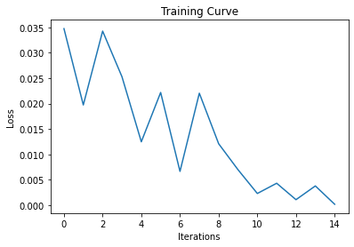

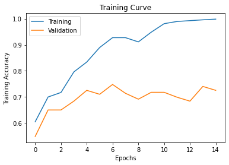

```python
net = GestureCNN()
use_cuda = True
if use_cuda and torch.cuda.is_available():
   net.cuda()
   print('CUDA is available!  Training on GPU ...')
else:
   print('CUDA is not available.  Training on CPU ...')

train(net, train_data, val_data, batch_size=32, num_epochs=15, learn_rate = 0.001)
```

### Part (c) “Overfit” to a Small Dataset - 5 pt

One way to sanity check our neural network model and training code is to check whether the model is capable of “overfitting” or “memorizing” a small dataset. A properly constructed CNN with correct training code should be able to memorize the answers to a small number of images quickly.

Construct a small dataset (e.g. just the images that you have collected). Then show that your model and training code is capable of memorizing the labels of this small data set.

With a large batch size (e.g. the entire small dataset) and learning rate that is not too high, You should be able to obtain a 100% training accuracy on that small dataset relatively quickly (within 200 iterations).

```python
#data path on google drive
!unzip '/content/gdrive/My Drive/APS360/Lab_3b_Dataset_small.zip' -d '/root/datasets'
```

[output not shown]

[output cut: 228 more lines]

[output not shown]

```python
#define training and test data directories
small_data_dir= '/root/datasets/Lab_3b_Dataset_small'
small_train_dir=os.path.join(small_data_dir, 'train/')
small_val_dir=os.path.join(small_data_dir, 'validation/')
small_test_dir=os.path.join(small_data_dir, 'test/')

#classes are folders in each directory with these names
small_classes = ['A', 'B', 'C', 'D', 'E', 'F', 'G', 'H', 'I']

#load and transform data using ImageFolder

#resize all images to 224 x 224
small_data_transform = transforms.Compose([transforms.CenterCrop([224,224]), transforms.ToTensor()])

small_train_data=datasets.ImageFolder(small_train_dir, transform=small_data_transform)
small_val_data= datasets.ImageFolder(small_val_dir, transform=small_data_transform)
small_test_data= datasets.ImageFolder(small_test_dir, transform=small_data_transform)

#print out some data stats
print('Num training images: ', len(small_train_data))
print('Num validation images: ', len(small_val_data))
print('Num test images: ', len(small_test_data))
```

```
Num training images:  27
Num validation images:  27
Num test images:  27
```

```
CUDA is available!  Training on GPU ...
Training Started...
Epoch 0: Training Accuracy 0.1111111111111111 |Validation Accuracy 0.1111111111111111
Epoch 1: Training Accuracy 0.14814814814814814 |Validation Accuracy 0.1111111111111111
Epoch 2: Training Accuracy 0.2222222222222222 |Validation Accuracy 0.14814814814814814
Epoch 3: Training Accuracy 0.14814814814814814 |Validation Accuracy 0.1111111111111111
Epoch 4: Training Accuracy 0.14814814814814814 |Validation Accuracy 0.14814814814814814
Epoch 5: Training Accuracy 0.14814814814814814 |Validation Accuracy 0.1111111111111111
Epoch 6: Training Accuracy 0.14814814814814814 |Validation Accuracy 0.1111111111111111
Epoch 7: Training Accuracy 0.18518518518518517 |Validation Accuracy 0.1111111111111111
Epoch 8: Training Accuracy 0.2962962962962963 |Validation Accuracy 0.1111111111111111
Epoch 9: Training Accuracy 0.25925925925925924 |Validation Accuracy 0.1111111111111111
Epoch 10: Training Accuracy 0.2962962962962963 |Validation Accuracy 0.1111111111111111
Epoch 11: Training Accuracy 0.3333333333333333 |Validation Accuracy 0.1111111111111111
Epoch 12: Training Accuracy 0.37037037037037035 |Validation Accuracy 0.14814814814814814
Epoch 13: Training Accuracy 0.4074074074074074 |Validation Accuracy 0.1111111111111111
Epoch 14: Training Accuracy 0.4444444444444444 |Validation Accuracy 0.14814814814814814
Epoch 15: Training Accuracy 0.5925925925925926 |Validation Accuracy 0.14814814814814814
Epoch 16: Training Accuracy 0.5925925925925926 |Validation Accuracy 0.14814814814814814
Epoch 17: Training Accuracy 0.5555555555555556 |Validation Accuracy 0.1111111111111111
Epoch 18: Training Accuracy 0.6296296296296297 |Validation Accuracy 0.14814814814814814
Epoch 19: Training Accuracy 0.6296296296296297 |Validation Accuracy 0.1111111111111111
Epoch 20: Training Accuracy 0.8148148148148148 |Validation Accuracy 0.2962962962962963
Epoch 21: Training Accuracy 0.8148148148148148 |Validation Accuracy 0.2962962962962963
Epoch 22: Training Accuracy 0.7777777777777778 |Validation Accuracy 0.2222222222222222
Epoch 23: Training Accuracy 0.8148148148148148 |Validation Accuracy 0.2222222222222222
Epoch 24: Training Accuracy 0.8888888888888888 |Validation Accuracy 0.25925925925925924
Epoch 25: Training Accuracy 0.9259259259259259 |Validation Accuracy 0.25925925925925924
Epoch 26: Training Accuracy 0.9629629629629629 |Validation Accuracy 0.3333333333333333
Epoch 27: Training Accuracy 0.9629629629629629 |Validation Accuracy 0.3333333333333333
Epoch 28: Training Accuracy 0.9629629629629629 |Validation Accuracy 0.2962962962962963
Epoch 29: Training Accuracy 0.9629629629629629 |Validation Accuracy 0.25925925925925924
Epoch 30: Training Accuracy 1.0 |Validation Accuracy 0.2962962962962963
Epoch 31: Training Accuracy 1.0 |Validation Accuracy 0.3333333333333333
Epoch 32: Training Accuracy 1.0 |Validation Accuracy 0.3333333333333333
Epoch 33: Training Accuracy 1.0 |Validation Accuracy 0.25925925925925924
Epoch 34: Training Accuracy 1.0 |Validation Accuracy 0.2962962962962963
Epoch 35: Training Accuracy 1.0 |Validation Accuracy 0.2962962962962963
Epoch 36: Training Accuracy 1.0 |Validation Accuracy 0.2962962962962963
Epoch 37: Training Accuracy 1.0 |Validation Accuracy 0.2962962962962963
```

[output cut: 150 more lines]

```
Epoch 188: Training Accuracy 1.0 |Validation Accuracy 0.25925925925925924
Epoch 189: Training Accuracy 1.0 |Validation Accuracy 0.25925925925925924
Epoch 190: Training Accuracy 1.0 |Validation Accuracy 0.25925925925925924
Epoch 191: Training Accuracy 1.0 |Validation Accuracy 0.25925925925925924
Epoch 192: Training Accuracy 1.0 |Validation Accuracy 0.25925925925925924
Epoch 193: Training Accuracy 1.0 |Validation Accuracy 0.25925925925925924
Epoch 194: Training Accuracy 1.0 |Validation Accuracy 0.25925925925925924
Epoch 195: Training Accuracy 1.0 |Validation Accuracy 0.25925925925925924
Epoch 196: Training Accuracy 1.0 |Validation Accuracy 0.25925925925925924
Epoch 197: Training Accuracy 1.0 |Validation Accuracy 0.25925925925925924
Epoch 198: Training Accuracy 1.0 |Validation Accuracy 0.25925925925925924
Epoch 199: Training Accuracy 1.0 |Validation Accuracy 0.25925925925925924
Total Training time: 57.11477732658386
Final Training Accuracy: 1.0
Final Validation Accuracy: 0.25925925925925924
```

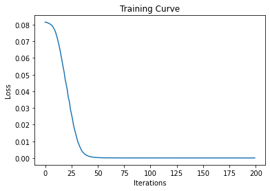

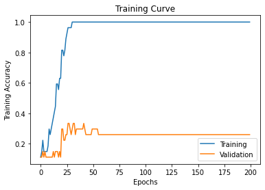

```python
small_net = GestureCNN()
use_cuda = True
if use_cuda and torch.cuda.is_available():
  small_net.cuda()
  print('CUDA is available!  Training on GPU ...')
else:
  print('CUDA is not available.  Training on CPU ...')

train(small_net, small_train_data, small_val_data, batch_size=27, num_epochs=200, learn_rate = 0.001)
```

### 3. Hyperparameter Search [10 pt]

### Part (a) - 1 pt

List 3 hyperparameters that you think are most worth tuning. Choose at least one hyperparameter related to the model architecture.

**Answer:** Learning rate, batch size, number of convolutional layers

### Part (b) - 5 pt

Tune the hyperparameters you listed in Part (a), trying as many values as you need to until you feel satisfied that you are getting a good model. Plot the training curve of at least 4 different hyperparameter settings.

```
CUDA is available!  Training on GPU ...
Training Started...
Epoch 0: Training Accuracy 0.31932773109243695 |Validation Accuracy 0.31954887218045114
Epoch 1: Training Accuracy 0.6622899159663865 |Validation Accuracy 0.650375939849624
Epoch 2: Training Accuracy 0.7153361344537815 |Validation Accuracy 0.6541353383458647
Epoch 3: Training Accuracy 0.8130252100840336 |Validation Accuracy 0.7105263157894737
Epoch 4: Training Accuracy 0.8487394957983193 |Validation Accuracy 0.6917293233082706
Epoch 5: Training Accuracy 0.9154411764705882 |Validation Accuracy 0.6879699248120301
Epoch 6: Training Accuracy 0.9327731092436975 |Validation Accuracy 0.7030075187969925
Epoch 7: Training Accuracy 0.9611344537815126 |Validation Accuracy 0.7142857142857143
Epoch 8: Training Accuracy 0.9837184873949579 |Validation Accuracy 0.7180451127819549
Epoch 9: Training Accuracy 0.9873949579831933 |Validation Accuracy 0.7142857142857143
Total Training time: 123.84412002563477
Final Training Accuracy: 0.9873949579831933
Final Validation Accuracy: 0.7142857142857143
```

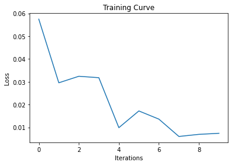

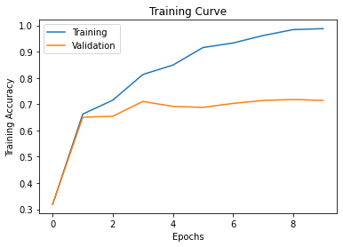

```python
net_1 = GestureCNN()
if use_cuda and torch.cuda.is_available():
  net_1.cuda()
  print('CUDA is available!  Training on GPU ...')
else:
  print('CUDA is not available.  Training on CPU ...')
train(net_1, train_data, val_data, batch_size=32, num_epochs=10, learn_rate = 0.001)
```

[output not shown]

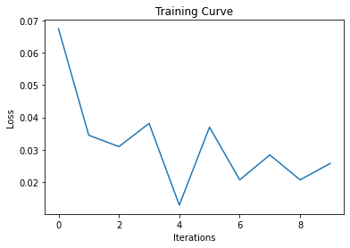

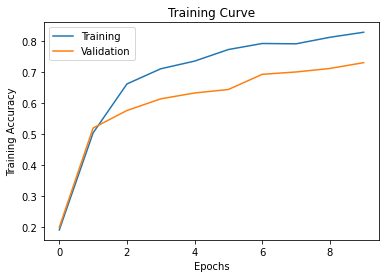

```python
net_1 = GestureCNN()
if use_cuda and torch.cuda.is_available():
  net_1.cuda()
  print('CUDA is available!  Training on GPU ...')
else:
  print('CUDA is not available.  Training on CPU ...')
train(net_1, train_data, val_data, batch_size=32, num_epochs=10, learn_rate = 0.001)
```

```
CUDA is available!  Training on GPU ...
Training Started...
Epoch 0: Training Accuracy 0.3403361344537815 |Validation Accuracy 0.3533834586466165
Epoch 1: Training Accuracy 0.39915966386554624 |Validation Accuracy 0.37593984962406013
Epoch 2: Training Accuracy 0.5887605042016807 |Validation Accuracy 0.5375939849624061
Epoch 3: Training Accuracy 0.6360294117647058 |Validation Accuracy 0.5639097744360902
Epoch 4: Training Accuracy 0.6727941176470589 |Validation Accuracy 0.6127819548872181
Epoch 5: Training Accuracy 0.6964285714285714 |Validation Accuracy 0.6278195488721805
Epoch 6: Training Accuracy 0.740546218487395 |Validation Accuracy 0.6691729323308271
Epoch 7: Training Accuracy 0.7647058823529411 |Validation Accuracy 0.6691729323308271
Epoch 8: Training Accuracy 0.7605042016806722 |Validation Accuracy 0.6691729323308271
Epoch 9: Training Accuracy 0.7988445378151261 |Validation Accuracy 0.6879699248120301
Total Training time: 80.48492407798767
Final Training Accuracy: 0.7988445378151261
Final Validation Accuracy: 0.6879699248120301
```

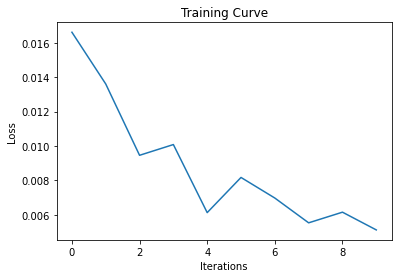

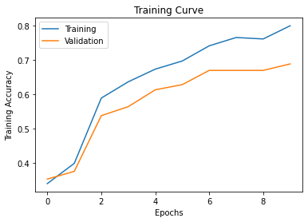

```python
net_2 = GestureCNN()
if use_cuda and torch.cuda.is_available():
  net_2.cuda()
  print('CUDA is available!  Training on GPU ...')
else:
  print('CUDA is not available.  Training on CPU ...')
train(net_2, train_data, val_data, batch_size=128, num_epochs=10, learn_rate = 0.001)
```

```
CUDA is available!  Training on GPU ...
Training Started...
Epoch 0: Training Accuracy 0.1055672268907563 |Validation Accuracy 0.10150375939849623
Epoch 1: Training Accuracy 0.11186974789915967 |Validation Accuracy 0.11278195488721804
Epoch 2: Training Accuracy 0.11186974789915967 |Validation Accuracy 0.11278195488721804
Epoch 3: Training Accuracy 0.11186974789915967 |Validation Accuracy 0.11278195488721804
Epoch 4: Training Accuracy 0.11186974789915967 |Validation Accuracy 0.11278195488721804
Epoch 5: Training Accuracy 0.11186974789915967 |Validation Accuracy 0.11278195488721804
Epoch 6: Training Accuracy 0.11186974789915967 |Validation Accuracy 0.11278195488721804
Epoch 7: Training Accuracy 0.11186974789915967 |Validation Accuracy 0.11278195488721804
Epoch 8: Training Accuracy 0.11186974789915967 |Validation Accuracy 0.11278195488721804
Epoch 9: Training Accuracy 0.11186974789915967 |Validation Accuracy 0.11278195488721804
Total Training time: 83.62594389915466
Final Training Accuracy: 0.11186974789915967
Final Validation Accuracy: 0.11278195488721804
```

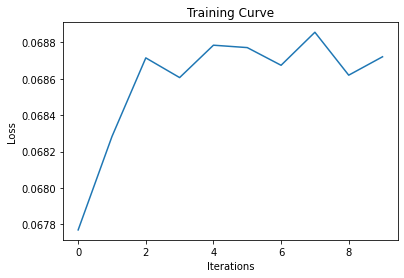

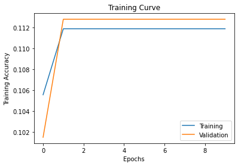

```python
net_3 = GestureCNN()
if use_cuda and torch.cuda.is_available():
  net_3.cuda()
  print('CUDA is available!  Training on GPU ...')
else:
  print('CUDA is not available.  Training on CPU ...')
train(net_3, train_data, val_data, batch_size=32, num_epochs=10, learn_rate = 0.005)
```

```
CUDA is available!  Training on GPU ...
Training Started...
Epoch 0: Training Accuracy 0.3398109243697479 |Validation Accuracy 0.34962406015037595
Epoch 1: Training Accuracy 0.5819327731092437 |Validation Accuracy 0.5902255639097744
Epoch 2: Training Accuracy 0.6890756302521008 |Validation Accuracy 0.6466165413533834
Epoch 3: Training Accuracy 0.7342436974789915 |Validation Accuracy 0.6353383458646616
Epoch 4: Training Accuracy 0.779936974789916 |Validation Accuracy 0.6428571428571429
Epoch 5: Training Accuracy 0.8072478991596639 |Validation Accuracy 0.6879699248120301
Epoch 6: Training Accuracy 0.803046218487395 |Validation Accuracy 0.6616541353383458
Epoch 7: Training Accuracy 0.8345588235294118 |Validation Accuracy 0.6428571428571429
Epoch 8: Training Accuracy 0.8665966386554622 |Validation Accuracy 0.6917293233082706
Epoch 9: Training Accuracy 0.8781512605042017 |Validation Accuracy 0.6616541353383458
Total Training time: 81.10305857658386
Final Training Accuracy: 0.8781512605042017
Final Validation Accuracy: 0.6616541353383458
```

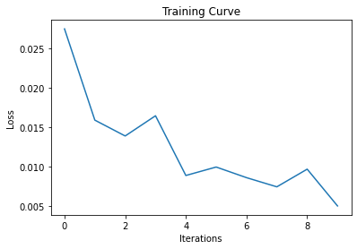

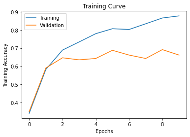

```python
net_4 = GestureCNN()
if use_cuda and torch.cuda.is_available():
  net_4.cuda()
  print('CUDA is available!  Training on GPU ...')
else:
  print('CUDA is not available.  Training on CPU ...')
train(net_4, train_data, val_data, batch_size=64, num_epochs=10, learn_rate = 0.001)
```

### Part (c) - 2 pt

Choose the best model out of all the ones that you have trained. Justify your choice.

```
CUDA is available!  Training on GPU ...
Training Started...
Epoch 0: Training Accuracy 0.31932773109243695 |Validation Accuracy 0.31954887218045114
Epoch 1: Training Accuracy 0.6622899159663865 |Validation Accuracy 0.650375939849624
Epoch 2: Training Accuracy 0.7153361344537815 |Validation Accuracy 0.6541353383458647
Epoch 3: Training Accuracy 0.8130252100840336 |Validation Accuracy 0.7105263157894737
Epoch 4: Training Accuracy 0.8487394957983193 |Validation Accuracy 0.6917293233082706
Epoch 5: Training Accuracy 0.9154411764705882 |Validation Accuracy 0.6879699248120301
Epoch 6: Training Accuracy 0.9327731092436975 |Validation Accuracy 0.7030075187969925
Epoch 7: Training Accuracy 0.9611344537815126 |Validation Accuracy 0.7142857142857143
Epoch 8: Training Accuracy 0.9837184873949579 |Validation Accuracy 0.7180451127819549
Epoch 9: Training Accuracy 0.9873949579831933 |Validation Accuracy 0.7142857142857143
Total Training time: 123.84412002563477
Final Training Accuracy: 0.9873949579831933
Final Validation Accuracy: 0.7142857142857143
```

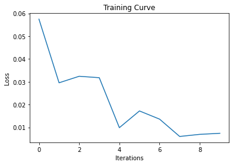

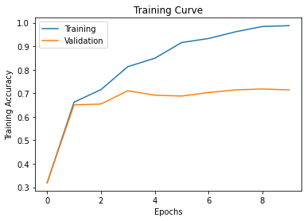

```python
net_1 = GestureCNN()
if use_cuda and torch.cuda.is_available():
  net_1.cuda()
  print('CUDA is available!  Training on GPU ...')
else:
  print('CUDA is not available.  Training on CPU ...')
train(net_1, train_data, val_data, batch_size=32, num_epochs=10, learn_rate = 0.001)
```

### Part (d) - 2 pt

Report the test accuracy of your best model. You should only do this step once and prior to this step you should have only used the training and validation data.

```python
test_loader = torch.utils.data.DataLoader(test_data, batch_size=32,
                                          num_workers=num_workers, shuffle=True)
test_accuracy = get_accuracy(net_1, test_loader)

print(("Test accuracy is {}").format(test_accuracy))
```

```
Test accuracy is 0.6973180076628352
```

### 4. Transfer Learning [15 pt]

For many image classification tasks, it is generally not a good idea to train a very large deep neural network model from scratch due to the enormous compute requirements and lack of sufficient amounts of training data.

One of the better options is to try using an existing model that performs a similar task to the one you need to solve. This method of utilizing a pre-trained network for other similar tasks is broadly termed **Transfer Learning**. In this assignment, we will use Transfer Learning to extract features from the hand gesture images. Then, train a smaller network to use these features as input and classify the hand gestures.

As you have learned from the CNN lecture, convolution layers extract various features from the images which get utilized by the fully connected layers for correct classification. AlexNet architecture played a pivotal role in establishing Deep Neural Nets as a go-to tool for image classification problems and we will use an ImageNet pre-trained AlexNet model to extract features in this assignment.

### Part (a) - 5 pt

Here is the code to load the AlexNet network, with pretrained weights. When you first run the code, PyTorch will download the pretrained weights from the internet.

```python
import torchvision.models
alexnet = torchvision.models.alexnet(pretrained=True)
```

The alexnet model is split up into two components: *alexnet.features* and *alexnet.classifier*. The first neural network component, *alexnet.features*, is used to compute convolutional features, which are taken as input in *alexnet.classifier*.

The neural network alexnet.features expects an image tensor of shape Nx3x224x224 as input and it will output a tensor of shape Nx256x6x6 . (N = batch size).

Compute the AlexNet features for each of your training, validation, and test data. Here is an example code snippet showing how you can compute the AlexNet features for some images (your actual code might be different):

```python
# img = ... a PyTorch tensor with shape [N,3,224,224] containing hand images ...

train_data_iter = iter(train_loader)
train_img, train_label = train_data_iter.next()
train_features = alexnet.features(train_img)

val_data_iter = iter(val_loader)
val_img, val_label = val_data_iter.next()
val_features = alexnet.features(val_img)

test_data_iter = iter(test_loader)
test_img, test_label = test_data_iter.next()
test_features = alexnet.features(test_img)

print("training:\n", train_features.shape)
print("validation:\n",val_features.shape)
print("test:\n",test_features.shape)
```

```
training:
 torch.Size([256, 256, 6, 6])
validation:
 torch.Size([256, 256, 6, 6])
test:
 torch.Size([256, 256, 6, 6])
```

**Save the computed features**. You will be using these features as input to your neural network in Part (b), and you do not want to re-compute the features every time. Instead, run *alexnet.features* once for each image, and save the result.

```python
alexnet = torchvision.models.alexnet(pretrained=True)

batch_size = 1 # save 1 file at a time
num_workers = 0
train_loader_alexnet = torch.utils.data.DataLoader(train_data, batch_size=batch_size,
                                           num_workers=num_workers, shuffle=True)
val_loader_alexnet = torch.utils.data.DataLoader(val_data, batch_size=batch_size,
                                           num_workers=num_workers, shuffle=True)
test_loader_alexnet = torch.utils.data.DataLoader(test_data, batch_size=batch_size,
                                           num_workers=num_workers, shuffle=True)

classes = ['A', 'B', 'C', 'D', 'E', 'F', 'G', 'H', 'I']
train_path = '/content/gdrive/My Drive/APS360/lab3/Features/train'
val_path = '/content/gdrive/My Drive/APS360/lab3/Features/validation'
test_path = '/content/gdrive/My Drive/APS360/lab3/Features/test'
# save features to folder as tensors
n = 0
for img, label in train_loader_alexnet:
  features = alexnet.features(img)
  features_tensor = torch.from_numpy(features.detach().numpy())
  folder_name = train_path + '/' + str(classes[label])
  if not os.path.isdir(folder_name):
    os.mkdir(folder_name)
  torch.save(features_tensor.squeeze(0), folder_name + '/' + str(n) + '.tensor')
  n += 1

n = 0
for img, label in val_loader_alexnet:
  features = alexnet.features(img)
  features_tensor = torch.from_numpy(features.detach().numpy())
  folder_name = val_path + '/' + str(classes[label])
  if not os.path.isdir(folder_name):
    os.mkdir(folder_name)
  torch.save(features_tensor.squeeze(0), folder_name + '/' + str(n) + '.tensor')
  n += 1

n = 0
for img, label in test_loader_alexnet:
  features = alexnet.features(img)
  features_tensor = torch.from_numpy(features.detach().numpy())
  folder_name = test_path + '/' + str(classes[label])
  if not os.path.isdir(folder_name):
    os.mkdir(folder_name)
  torch.save(features_tensor.squeeze(0), folder_name + '/' + str(n) + '.tensor')
  n += 1
```

```python
# Load features from folder
feature_train_data = torchvision.datasets.DatasetFolder(train_path, loader=torch.load, extensions=('.tensor'))
feature_val_data = torchvision.datasets.DatasetFolder(val_path, loader=torch.load, extensions=('.tensor'))
feature_test_data = torchvision.datasets.DatasetFolder(test_path, loader=torch.load, extensions=('.tensor'))

# Prepare Dataloader
batch_size = 32
num_workers = 0
feature_train_loader = torch.utils.data.DataLoader(feature_train_data, batch_size=batch_size,
                                           num_workers=num_workers, shuffle=True)
feature_val_loader = torch.utils.data.DataLoader(feature_val_data, batch_size=batch_size,
                                           num_workers=num_workers, shuffle=True)
feature_test_loader = torch.utils.data.DataLoader(feature_test_data, batch_size=batch_size,
                                           num_workers=num_workers, shuffle=True)


train_dataiter = iter(feature_train_loader)
train_feature, train_label = train_dataiter.next()
print("training:")
print(train_feature.shape)
print(train_label.shape)

val_dataiter = iter(feature_val_loader)
val_feature, val_label = val_dataiter.next()
print("validation:")
print(val_feature.shape)
print(val_label.shape)

test_dataiter = iter(feature_test_loader)
test_feature, test_label = test_dataiter.next()
print("test:")
print(test_feature.shape)
print(test_label.shape)
```

```
training:
torch.Size([32, 256, 6, 6])
torch.Size([32])
validation:
torch.Size([32, 256, 6, 6])
torch.Size([32])
test:
torch.Size([32, 256, 6, 6])
torch.Size([32])
```

### Part (b) - 3 pt

Build a convolutional neural network model that takes as input these AlexNet features, and makes a prediction. Your model should be a subclass of nn.Module.

Explain your choice of neural network architecture: how many layers did you choose? What types of layers did you use: fully-connected or convolutional? What about other decisions like pooling layers, activation functions, number of channels / hidden units in each layer?

Here is an example of how your model may be called:

**Answer:**

I choose 1 convolutional layers for identifying the features, no maxpooling layer since the output size is small(6x6), 2 fully connected layers, and 1 output layers. The output size for first nn.linear is 32, for second nn.linear is 9.

The input data for conv1 is 256x6x6, o=(i-k)+2p+1=(6-5)+2x2+1=1+4+1=6, the size then is 160x6x6. Then using relu as activation function.

```python
class CNNClassifier(nn.Module):
    def __init__(self):
          self.name = "CNNClassifier"
          super(CNNClassifier, self).__init__()
          self.conv1 = nn.Conv2d(256, 160, 5, padding=2) #in_channels=256, out_chanels=160, kernel_size=5, padding=2
          self.fc1 = nn.Linear(160*6*6, 32)
          self.fc2 = nn.Linear(32, 9)

    def forward(self, x):
          x = F.relu(self.conv1(x)) #activation function
          x = x.view(-1, 160*6*6)
          x = F.relu(self.fc1(x))#activation function
          x = self.fc2(x)
          return x
```

```python
# features = ... load precomputed alexnet.features(img) ...
#output = model(features)
#prob = F.softmax(output)
```

### Part (c) - 5 pt

Train your new network, including any hyperparameter tuning. Plot and submit the training curve of your best model only.

Note: Depending on how you are caching (saving) your AlexNet features, PyTorch might still be tracking updates to the **AlexNet weights**, which we are not tuning. One workaround is to convert your AlexNet feature tensor into a numpy array, and then back into a PyTorch tensor.

[output not shown]

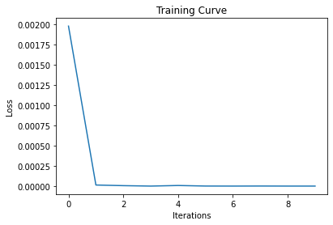

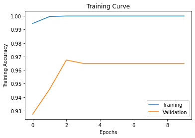

```python
net_5 = CNNClassifier()
use_cuda = True
if use_cuda and torch.cuda.is_available():
  net_5.cuda()
  print('CUDA is available!  Training on GPU ...')
else:
  print('CUDA is not available.  Training on CPU ...')

train(net_5, feature_train_data, feature_val_data, batch_size=32, num_epochs=10, learn_rate = 0.001)
```

```python
#tensor = torch.from_numpy(tensor.detach().numpy())
```

### Part (d) - 2 pt

Report the test accuracy of your best model. How does the test accuracy compare to Part 3(d) without transfer learning?

**Answer:** The new test accuracy is 0.9217462932454695, which is much higher than the result in part3(d) that only 0.6973180076628352. Since AlexNet extracts the important features of the dataset and reduces size of the input data, its performance is much better.

```python
feature_test_loader = torch.utils.data.DataLoader(feature_test_data, batch_size=32,
                                           num_workers=num_workers, shuffle=True)
feature_test_accuracy = get_accuracy(net_5, feature_test_loader)
print(("Test accuracy is {}").format(feature_test_accuracy))
```

[output not shown]

### 5. Additional Testing [5 pt]

As a final step in testing we will be revisiting the sample images that you had collected and submitted at the start of this lab. These sample images should be untouched and will be used to demonstrate how well your model works at identifying your hand guestures.

Using the best transfer learning model developed in Part 4. Report the test accuracy on your sample images and how it compares to the test accuracy obtained in Part 4(d)? How well did your model do for the different hand guestures? Provide an explanation for why you think your model performed the way it did?

**Answer:** The test accuracy on sample images is 1, which higher than the test accuracy obtained in part4(d). This indicates my model can accurately classify every different hand guestures, all predicts are correct. The test accuracy reach 1 becasue among 27 images I used is similar to each other, each letter has three similar images. I could try to test more images.

```python
#data path on google drive
!unzip '/content/gdrive/My Drive/APS360/sample.zip' -d '/root/datasets'
```

[output not shown]

[output cut: 17 more lines]

[output not shown]

```python
#define training and test data directories
sample_dir= '/root/datasets/sample/test'
#sample_data_dir=os.path.join(sample_dir, 'zhao_1005092427/')


classes = ['A', 'B', 'C', 'D', 'E', 'F', 'G', 'H', 'I']
#resize all images to 224 x 224
sample_data_transform = transforms.Compose([transforms.CenterCrop([224,224]), transforms.ToTensor()])
#sample_data= datasets.ImageFolder(sample_data_dir, transform=sample_data_transform)
sample_data =datasets.ImageFolder(sample_dir,transform=sample_data_transform)
```

```python
print(sample_data)
```

```
Dataset ImageFolder
    Number of datapoints: 27
    Root location: /root/datasets/sample/test
    StandardTransform
Transform: Compose(
               CenterCrop(size=[224, 224])
               ToTensor()
           )
```

```python
alexnet = torchvision.models.alexnet(pretrained=True)

batch_size = 1 # save 1 file at a time
num_workers = 0
classes = ['A', 'B', 'C', 'D', 'E', 'F', 'G', 'H', 'I']
sample_loader_alexnet = torch.utils.data.DataLoader(sample_data, batch_size=batch_size,
                                           num_workers=num_workers, shuffle=True)



sample_path = '/content/gdrive/My Drive/APS360/lab3/FeaturesSample/test'
# save features to folder as tensors
n = 0
for img, label in sample_loader_alexnet:
  features = alexnet.features(img)
  features_tensor = torch.from_numpy(features.detach().numpy())
  folder_name = sample_path + '/' + str(classes[label])
  if not os.path.isdir(folder_name):
    os.mkdir(folder_name)
  torch.save(features_tensor.squeeze(0), folder_name + '/' + str(n) + '.tensor')
  n += 1
```

```python
# Load features from folder
feature_sample_data = torchvision.datasets.DatasetFolder(sample_path, loader=torch.load, extensions=('.tensor'))

# Prepare Dataloader
batch_size = 32
num_workers = 0

feature_sample_loader = torch.utils.data.DataLoader(feature_sample_data, batch_size=batch_size,
                                           num_workers=num_workers, shuffle=True)

sample_dataiter = iter(feature_sample_loader)
sample_feature, sample_label = sample_dataiter.next()
print("test:")
print(sample_feature.shape)
print(sample_label.shape)
```

```
test:
torch.Size([27, 256, 6, 6])
torch.Size([27])
```

```python
sample_data_accuracy = get_accuracy(net_5, feature_sample_loader)
print(("Test accuracy is {}").format(sample_data_accuracy))
```

```
Test accuracy is 1.0
```

```python
#%%shell
#jupyter nbconvert --to html /Lab_3_Gesture_Recognition.ipynb
```